# Area2D

# Area2D detects when things enter and exit it

`Area2D` creates a perimeter that warns you when objects enter or exit it.

In this guide, you’ll learn to:

- Set up an `Area2D` node and use its key methods and signals.
- Let the player open a chest, read a board, activate a pressure plate, or trigger other interactive entities.
- Attract items like coins towards the player when they’re close.
- Make an enemy pursue the player when the player enters the enemy’s detection area.
- Create hitboxes.
- Locally change the physics engine’s gravity and create some kind of “black hole.”

Contents:

- Setting up an Area2D node
- Area2D’s key methods and signals
  - Detecting when bodies and areas enter or leave an area
  - Getting a list of overlapping areas and bodies
  - Affecting gravity for physical objects
- How to use Area2D in practice
  - Displaying a message automatically when near a sign
  - Attracting coins to the player
  - Pursuing a target
  - Opening a door with a pressure plate
  - Attract rigid bodies to a black hole
  - Hit Boxes
  - Opening Chests
  - Selecting units in a tactical game
- Your questions
  - What can an Area2D detect?
  - When should I use an area instead of a static or kinematic body?
  - Discriminating entering bodies
  - What are the different signals for?
  - Determining who handles the action

## Setting up an Area2D node

Before we dive in, it’s important to understand the basic structure of an `Area2D`.

A functional `Area2D` is made of three components:

1. The `Area2D` itself, for detecting entering and exiting bodies.
2. One or more `CollisionShape2D` or `CollisionPolygon2D`, that define the polygon(s) of the Area.
3. Each collision shape has a shape resource associated with them (probably a `RectangleShape2D` or a `CircleShape2D`, but could also be another `Shape2D`), while the collision polygon has an array of points.

The final structure presents itself as such (picture below with a `CollisionShape2D`)

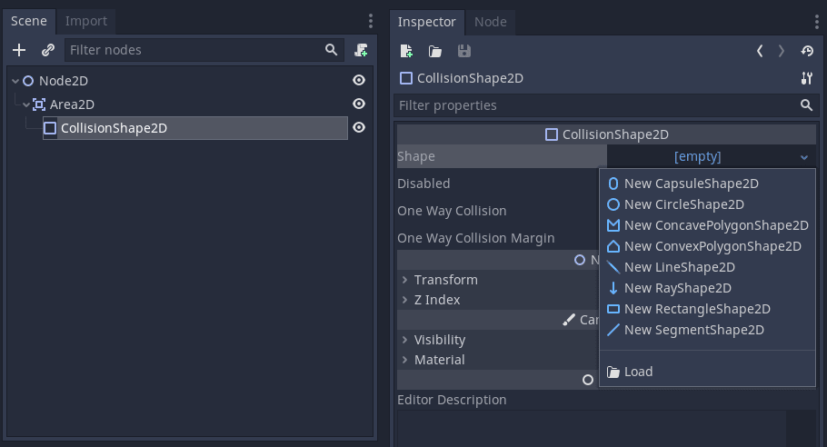

The node tree structure to the left, showing an Area2D with a CollisionShape2D child, and the Inspector to the right, allowing to choose the shape

This is the same structure you’ll find in `KinematicBody2D` or `StaticBody2D`.

One minor detail, but one that often trips people in the beginning, is to make sure you set your collision *Layers* and *Masks* properly. We made a tutorial dedicated to them if you need a primer: [Using Physics Layers and Masks in Godot 3.1](https://youtu.be/UZu8NwlkXcU).

With that out of the way, let’s start!

## Area2D’s key methods and signals

Most use cases we’ll show you for this node rely on a handful of signals, methods, and properties.

### Detecting when bodies and areas enter or leave an area

A “body” is a physical body, such as `KinematicBody2D` or `RigidBody2D`.

To trigger an action when a `KinematicBody2D` enters and exits an area, connect the `body_entered` and `body_exited` signals:

```
func _on_Area2D_body_entered(body: Node) -> void:
    print("a node overlapped this area")

func _on_Area2D_body_exited(body: Node) -> void:
    print("a node stopped overlapping this area")
```

To detect if another `Area2D` entered or left the area, use `area_entered` and `area_exited`.

```
func _on_Area2D_area_entered(area: Area2D) -> void:
    print("another area overlapped this area")

func _on_Area2D_area_exited(area: Area2D) -> void:
    print("another area stopped overlapping this area")
```

### Getting a list of overlapping areas and bodies

You can also get a list of everything inside the area thanks to two convenient methods: `get_overlapping_bodies()` and `get_overlapping_areas()`.

This is useful in many cases, like when dealing damage with explosives. The player throws a grenade and after some time, it explodes and deals damage to all enemies in an area.

Here’s how you could use `get_overlapping_bodies()` to do so.

```
class_name Grenade
extends Area2D

var damage := 3

func explode() -> void:
    for body in get_overlapping_bodies():
        if body.has_method("take_damage"):
            body.take_damage(damage)
```

You could always use the signals above as an alternative, but you’ll find cases where the `get_overlapping_areas()` and `get_overlapping_bodies()` methods are more convenient.

### Affecting gravity for physical objects

The second thing `Area2D` can do is to override some physics properties for `RigidBody2D` objects overlapping it.

To make an area affect physics, you set its *Space Override* property. If you have multiple overlapping areas, you also want to set the *Priority* setting to give an area priority other another.

*Space Override* needs to be set to one of the following options:

- *Combine*: the area’s physics properties combine with normal physics.
- *Replace*: the area’s physics properties replaces physics (Lower priority areas are ignored).
- *Combine-Replace*: Combines with higher priority areas, ignores lower priority areas.
- *Replace-Combine*: Replaces everything before, but combines with lower priority areas.

Settings you can change are *Gravity*, *Gravity Vector*, *Linear Damping*, *Angular Damping*, and finally the *Gravity Point* toggle, which creates an attractor, like in our demo.

## How to use Area2D in practice

Here are concrete use cases for areas. Here, we’re focusing on the area-specific code.

### Displaying a message automatically when near a sign

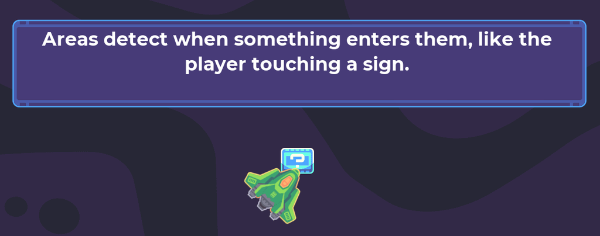

If you want to automatically display text when the player approaches a sign, you can attach an area to the sign.

[figure not shown]

In the image, the child *Sign* node is an `Area2D`.

Then, connect the area’s relevant signals to the sign’s script.

```
onready var _sign: Area2D = $Sign


func _ready() -> void:
    _text_frame.hide()
    _sign.connect("body_entered", self, "_on_Sign_body_entered")
    _sign.connect("body_exited", self, "_on_Sign_body_exited")
```

In the callback functions, you can call methods to display and hide a message, respectively.

```
func _on_Sign_body_entered(_body: PhysicsBody2D):
    show_message()


func _on_Sign_body_exited(_body: PhysicsBody2D):
    hide_message()
```

### Attracting coins to the player

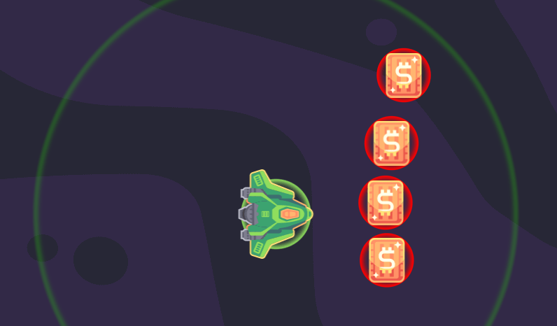

You can use two areas to attract coins to the player:

1. One, large, instanced in the player scene (the large green circle above).
2. The second, smaller, is the coin itself (the small red circles).

There are two ways to code the coins moving towards the player. You can either code that on the player’s area or on the coins themselves.

In this example, the code to move and destroy the coins lives in the `Coin` class.

The *Coin* is an `Area2D` with its `body_entered` signal connected to an `_on_body_entered()` method.

We use the signal to detect the player touching it.

```
func _ready() -> void:
    connect("body_entered", self, "_on_body_entered")

# We destroy the coin upon detecting a collision with the player.
func _on_body_entered(_body: Node) -> void:
    queue_free()
```

Here’s the scene setup:

[figure not shown]

Here’s how we get every coin moving smoothly towards the player, using the follow steering equation and `Area2D.get_overlapping_areas()`.

```
extends Area2D

# The drag is a divider which controls the coin's acceleration and the time it
# takes to change direction. A higher value makes it less reactive.
const DRAG := 14.0
var max_speed := 400.0

var _velocity := Vector2.ZERO

func _physics_process(delta: float) -> void:
    # We detect attractors using `get_overlapping_areas()`
    var attractors := get_overlapping_areas()

    # If there is one or more overlapping areas, we steer towards the first one.
    if attractors:
        # The desired velocity is a vector of length `max_speed` pointing
        # towards the player.
        var desired_velocity: Vector2 = (
            (attractors[0].global_position - global_position).normalized()
            * max_speed
        )
        # The follow steering equation works like so:
        #
        # 1. We calculate the difference between the desired and current velocity.
        # 2. We add a fraction of that difference to the current velocity.
        var steering := desired_velocity - _velocity
        _velocity += steering / DRAG
    # In this basic example, we instantly stop the coin's movement if the
    # player gets too far.
    else:
        _velocity = Vector2.ZERO

    position += _velocity * delta
```

### Pursuing a target

In this example, we use an area to detect when the player is near an enemy. If so, the enemy moves towards the player.

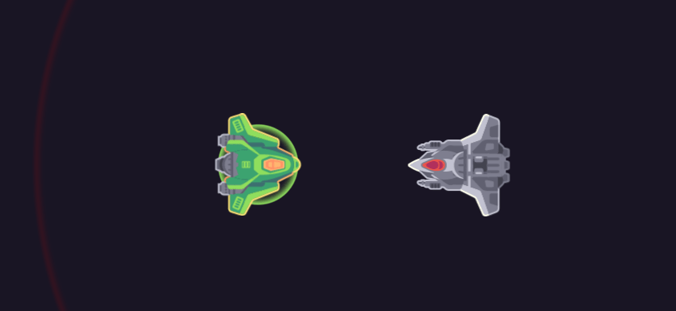

Here, all we need is an area attached to the enemy, named *DetectionArea* below.

[figure not shown]

We connect the area’s `body_entered` and `body_exited` signals to the root *Enemy* node and keep track of the player with a variable.

```
class_name Enemy
extends KinematicBody2D

var _target: Player = null

func _on_DetectionArea_body_entered(body: Player) -> void:
    _target = body

func _on_DetectionArea_body_exited(_body: Player) -> void:
    _target = null
```

In `_physics_process()`, if there’s a target, we use the follow steering equation to move towards it.

```
func _physics_process(_delta: float) -> void:
    # In the absence of a target, we return from the function, causing the
    # enemy to stay idle.
    if not _target:
        return

    # With a target, we steer towards it.
    # The equation is the same as in the previous example.
    var direction := global_position.direction_to(_target.global_position)
    var desired_velocity := direction * speed
    var steering := desired_velocity - _velocity

    _velocity += steering / 20.0

    # We rotate to look where we're moving.
    rotation = _velocity.angle() + PI / 2
    # Finally, we move towards the target
    move_and_slide(_velocity)
```

### Opening a door with a pressure plate

You can make a pressure plate with an `Area2D`.

In this example, we made a plate such that when the player touches it, a door opens or closes.

To that end, we store a `NodePath` to a door on the pressure plate and call a specific function on it.

```
# PressurePlate.gd
extends Area2D

# We export the target path to be able to set it when designing the level.
export var target_path: NodePath
# When the pressure plate is ready, we get the node from the path, or `null`
# if the path is invalid.
onready var _target: Node2D = get_node_or_null(target_path)
```

We connect the pressure plate’s `body_entered` signal to itself. There, we can call a method on the target.

```
func _on_body_entered(_body: PhysicsBody2D):
    # We ensure there is a target and it has the method we want to call.
    # Here, we named it `activate()`, and it opens and closes the door.
    if _target and _target.has_method("activate"):
        _target.activate()
```

### Attract rigid bodies to a black hole

In this demo, we use an `Area2D` to override physics properties in a circle, turning it into a black hole. When the player passes over a pressure plate, the area attracts rocks towards its center.

The pressure plate is the same we described in the last section, and rocks are `RigidBody2D` nodes.

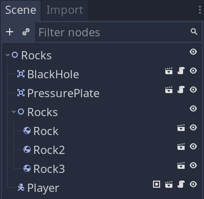

Initially, we set the *Space Override* property of the *BlackHole* to *Disabled*. This way, the node won’t attract the rocks when starting the scene.

We also turn on the *Gravity Point* property, so the *BlackHole* acts as an attractor.

We use a script to change the node’s *Space Override* upon touching the pressure plate. It causes all rigid bodies inside the area to be attracted to move towards the area’s center.

```
# BlackHole.gd
extends Area2D

func activate() -> void:
    space_override = Area2D.SPACE_OVERRIDE_REPLACE
```

Here’s the relevant code inside the PressurePlate’s script.

```
func _ready() -> void:
    connect("body_entered", self, "_on_body_entered")
    connect("body_exited", self, "_on_body_exited")


func _on_body_entered(_body: PhysicsBody2D):
    _sprite.texture = texture_pressed
    if _target and _target.has_method("activate"):
        _target.activate()


func _on_body_exited(_body: PhysicsBody2D):
    _sprite.texture = texture_normal
```

### Hit Boxes

In games, we use hit and hurt boxes to designate areas that respectively cause and receive damages. In Godot, we use area nodes for that.

In this demo, we have a *HitboxWeapon* scene with an `Area2D` acting like a hit box.

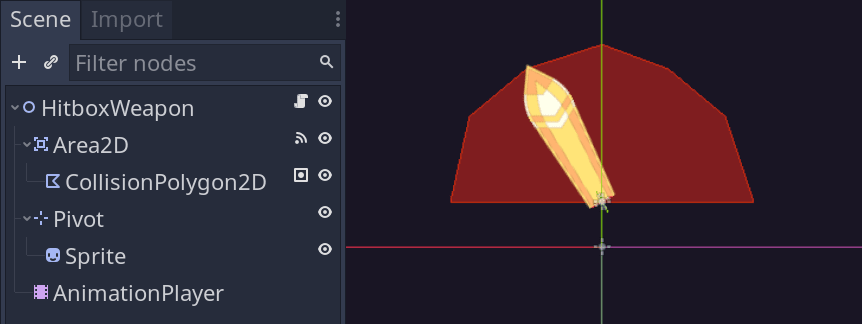

In the scene, we turn off the node’s *Monitoring* property so it doesn’t detect any collisions. We enable it only when the player presses the attack action, for the duration of a short attack animation.

This ensures that the weapon won’t deal damage unless the player is attacking.

We toggle the *Monitoring* property directly in the attack animation, using the `AnimationPlayer`.

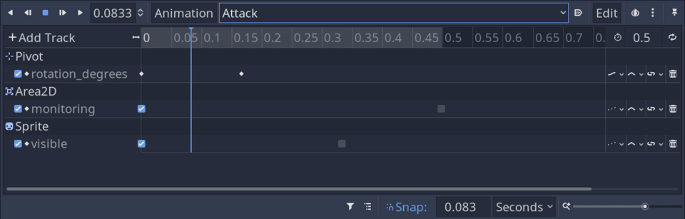

To deal damage, we connect the `body_entered` signal of the `Area2D` to the root node. There, we call a `take_damage()` function on the body the area touched.

```
func _on_Area2D_body_entered(body: PhysicsBody2D) -> void:
    # We use duck-typing to ensure the colliding entity can take damage.
    if body.has_method("take_damage"):
        body.take_damage()
```

Remember to set the area’s collision mask to only detect potential targets. Doing so throughout your project greatly improves performance and can help simplify code.

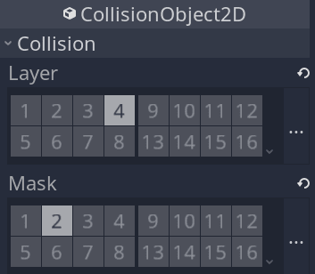

### Opening Chests

In this demo, we present a chest that the player opens or closes by pressing a key.

To detect if the character is close enough to the chest when pressing the key, we attach an `Area2D` to the chest.

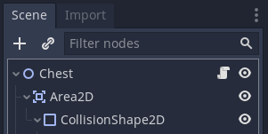

When the player press space, we check if the player is inside that area. If so, we open or close the chest. We do this with the following code in the `_unhandled_input` function:

```
onready var _area := $Area2D

func _unhandled_input(event: InputEvent) -> void:
    if event.is_action_pressed("interact"):
        # If the player presses "interact", we loop over all overlapping bodies.
        for body in _area.get_overlapping_bodies():
            # We ensure the player is overlapping with the chest's area.
            if body is Player:
                # If so, we toggle the chest, consume the input event, and
                # return the function to end the loop.
                toggle_open_chest()
                get_tree().set_input_as_handled()
                return
```

### Selecting units in a tactical game

You can use areas to let your players select units in a tactical game.

[figure not shown]

This demo shows how to select single units and multiple units using a box selection.

We can do this using two scenes: The first is our selection box, an `Area2D` with a rectangular `CollisionShape2D`. The second is our selectable object.

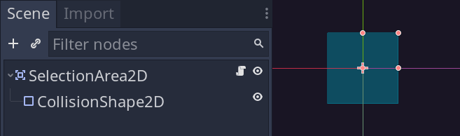

For the `Area2D`, we turn off its *Monitorable* and *Monitoring* properties and set it to mask a physics layer. This `Area2D` should only detect other nodes; nothing should detect it.

Also, we’re not drawing a selection at the start of the game, so we don’t want the area detecting anything to start.

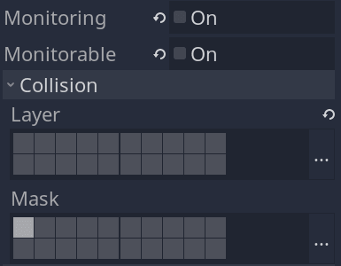

The second scene is a selectable object. In our demo, this object is a ship unit. You can use any collision shape for it; we went with a circle.

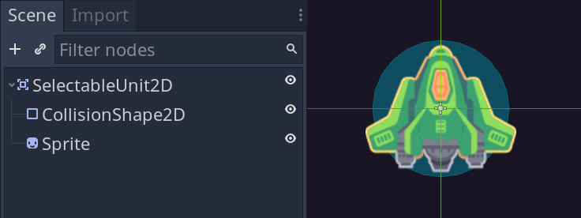

This area should be *Monitorable* and doesn’t need any physics mask since the selection area detects it.

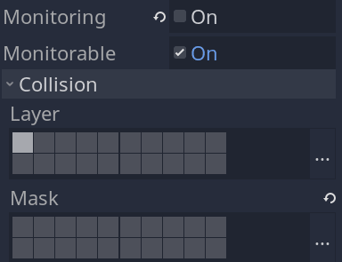

From there, everything happens in the selection areas script.

The logic works like so:

- When the player clicks, we start selecting.
- Every frame, we move the box and store a list of selectable objects inside the box.
- Upon releasing the mouse, we end the selection process.
  - Then, we check the size of the selection box. If its below a threshold, we only select the unit in front visually.
  - If the box is larger than our threshold, we select all units overlapping with it.

We start with the properties. Most notably, we don’t directly select units: we store units overlapping the area into an array during the box selection.

That way, we can sort them and process them later to pick what the player wants to select.

```
# This represents our selection rectangle. We use it to draw the selection and
# update the area's shape.
var selection_rect := Rect2(Vector2.ZERO, Vector2.ZERO)
# When the player releases the mouse, we store the selection in this array.
var selected_units := []
## Distance threshold in pixels beyond which we start a box selection and select
## multiple units.
var box_selection_distance_threshold := 3.0
## The list of selectable entities that overlap the selection rectangle.
var _detected_units := []

onready var _collision_shape: CollisionShape2D = $CollisionShape2D
```

We initiate, cancel, or end the selection process using the `_unhandled_input()` callback.

```
func _ready() -> void:
    # We use processing to update the box selection every frame, which we don't
    # want to do by default.
    set_process(false)


func _unhandled_input(event: InputEvent) -> void:
    if event.is_action_pressed("ui_cancel") and monitoring:
        cancel_selection()

    if not event.is_action("click"):
        return

    # We start and end the selection process by toggling the monitoring property.
    if event.is_action_pressed("click"):
        start_selection(event.position)
    elif event.is_action_released("click"):
        end_selection(event.position)
```

When starting a selection, we move the `selection_rect` to the mouse, enable *Monitoring* on the area, and turn on `_process()`.

```
func start_selection(mouse_position: Vector2) -> void:
    selection_rect.position = mouse_position
    _toggle_selection_state(true)


func _toggle_selection_state(value: bool) -> void:
    monitoring = value
    set_process(monitoring)
```

Inside `_process()`, we update our selection rectangle and collision shape every frame before asking the area for what it found.

After that, we update the selection and update the drawing on-screen for instant visual feedback.

```
func _process(delta: float) -> void:
    # When a selection is active, we update the rectangle every frame as well as
    # the area's rectangle collision shape.
    selection_rect.end = get_local_mouse_position()
    _collision_shape.shape.extents = selection_rect.size / 2.0
    _collision_shape.position = selection_rect.position + _collision_shape.shape.extents

    # The area detects all overlapping units for us.
    _detected_units = get_overlapping_areas()
    # If the player only clicks, they want to select a single unit. We compare
    # the selection box's length to a threshold to detect that.
    if selection_rect.size.length() < box_selection_distance_threshold and _detected_units:
        select_top_node(_detected_units)
    else:
        selected_units = _detected_units
    update()
```

When the player clicks a single unit, we sort all the objects under the mouse cursor by the scene tree to detect which unit is on top.

```
func select_top_node(nodes: Array) -> void:
    nodes.sort_custom(self, "_sort_by_tree_order")
    selected_units = [nodes[0]]


func _sort_by_tree_order(a, b) -> bool:
    return a.get_position_in_parent() > b.get_position_in_parent()
```

Here’s the drawing code, which draws a box around every selected unit.

```
func _draw() -> void:
    # This condition clears the selection rectangle as soon as the player
    # releases the mouse button.
    if monitoring:
        draw_rect(selection_rect, SELECTION_COLOR, false, SELECTION_OUTLINE_WIDTH)

    # We draw a rectangle around every unit.
    for unit in selected_units:
        draw_rect(
            Rect2(unit.position, Vector2.ZERO).grow(100.0),
            SELECTION_COLOR,
            false,
            SELECTION_OUTLINE_WIDTH
        )
```

Lastly, when the player ends the selection, we calculate selected units one last time.

```
func end_selection(mouse_position: Vector2) -> void:
    selection_rect.end = mouse_position
    _toggle_selection_state(false)
    if _detected_units and selection_rect.size.length() < box_selection_distance_threshold:
        select_top_node(_detected_units)
```

And that gives you a solid base for single units and box selection.

#### Is there an alternative to areas for selections?

You could create a selection system manually with the `Rect2` class. You can use its `has_point()`, `encloses()`, or `intersects()` methods to detect objects to select.

Using an `Area2D`, we can only select objects when they touch the area’s shape, completely enclosed or not. With `Rect2.encloses()`, you can select objects only if they’re completely inside the selection box.

`Rect2` selection works great if you’re selecting objects by their bounding box or origin point. As soon as they have different shapes, it becomes trickier to calculate which objects the selection box encloses.

Unlike `Rect2`, `Area2D` can select objects of any shape, and the physics engine compartmentalizes physics objects in the game world to optimize performance.

As a result, it’s usually fast enough to use areas compared to the more manual approach with rectangles.

## Your questions

### What can an Area2D detect?

An `Area2D` specifically detects other `CollisionObject2D`. These are:

- `Area2D` itself.
- `StaticBody2D`, used for walls.
- `KinematicBody2D`, used for creatures.
- `RigidBody2D`, used for props.

`Area2D` cannot detect any other type of body.

### When should I use an area instead of a static or kinematic body?

Unlike `KinematicBody2D`, `RigidBody2D`, and `StaticBody2D`, the `Area2D` node doesn’t handle collisions through the physics engines. It only detects when something enters, overlaps, or leaves its collision shape(s).

Use an `Area2D` if you need to:

- Detect objects entering or exiting a certain area.
- Detect the mouse entering or exiting a certain area.
- Detect clicks, drags, or other inputs and can’t use a `Button` or a `TouchScreenButton`. For example, you can use this to detect swiping motions on a touch device.
- Create an area where physics act differently, such as lowering gravity underwater. This feature affects `RigidBody2D` nodes.
- Have the game’s audio flow through a specific mixer channel, for example, to apply a low-pass filter to the game’s sounds underwater.

In contrast, `StaticBody2D`, `KinematicBody2D`, and `RigidBody2D` are *physics bodies*. They inherit properties from `PhysicsBody2D`, and don’t allow overlap. When a collision happens with them, the physics engine pushes kinematic and rigid bodies outside of walls and other bodies.

Here’s when to use them instead of `Area2D`:

- Use a `StaticBody2D` for solid walls or grounds, even for objects that affect the player’s movement, like conveyor belts.
- Use a `KinematicBody2D` for any physical object you want to move manually, with fine control. This is the most commonly used node for characters in Godot.
- Use a `RigidBody2D` for any physical object you want to move using physics properties like gravity and forces. While you typically use them for physics games like Angry Birds, some studios also use rigid body physics for all their game characters.

### Discriminating entering bodies

You now know how to detect that a body entered an area, but how can you know *which* body?

Common solutions involve:

- Using a class name and the `is` keyword.
- Using Godot’s groups feature.
- Using duck typing.
- Using nodes and composition.

#### Using a class name

If you use a class name somewhere like so:

```
# player.gd
class_name Player
```

You can then reference it in your collision.

```
func _on_Area2D_body_entered(body: Node) -> void:
    if body is Player:
        print("the player overlapped this area")
```

**Benefits**: This is the safest and cleanest way to verify the type of object. This is great to detect a one-off script (`Player`) or a class of object (`Enemy`).

**Limitations**: You cannot always use the class name. For example, you may have many flying creatures: some that are `Player`, some that are `Enemy`, and some that are `NPC`. This would be a classical [Diamond problem](https://en.wikipedia.org/wiki/Multiple_inheritance#The_diamond_problem).

If that’s your case, look into the next options!

#### Using groups

You can add a node to groups, either through the *Node* tab on the right of the editor, or in code:

```
func _ready() -> void:
    add_to_group("collectible")
```

Node groups work like a tagging system in other programs: they associate nodes with a given keyword.

You can then use groups to check if the overlapping body is part of that group:

```
func _on_Area2D_body_entered(body: Node) -> void:
    if body.is_in_group("collectible"):
        print("a collectible overlapped this area")
```

**Benefits**: Groups are an easy and straightforward way to tag nodes. You can use them to access many nodes at a time with `get_tree().get_nodes_in_group("collectible")` and call a function on many nodes with `get_tree().call_group("collectible", "collect")`.

**Limitations**: You can assign a group to any node, so a group doesn’t guarantee a node has a specific method. Also, it’s easy to assign nodes to the wrong groups, forget to assign groups, or make a typo when setting a node’s group, as their name is a text string.

#### Using duck typing

Duck typing is the process of only checking the properties you need. The saying goes: “if it walks like a duck, and quacks like a duck, it is a duck.”

In Godot, you can check if an object has a given method or property respectively with `has_method()` and `has_property()`.

```
func _on_Area2D_body_entered(body: Node) -> void:
    if body.has_method("take_damage"):
        body.take_damage()
```

**Benefits**: This is straightforward and has no frills. If you need a specific method, verify it exists, then call it.

**Limitations**: The code becomes more complex when you need to verify multiple properties. In Godot 4, using type hints and checks gives you more performance.

#### Using composition

You can use nodes as components in Godot. This is an alternative to duck typing: adding nodes with specific functionality that act on their parent.

```
func _on_Area2D_body_entered(body: Node) -> void:
    var health_node := body.get_node_or_null("Health")
    if health_node:
        health_node.take_damage()
```

You can combine that with any checks you want (`class_name` checks or duck typing).

**Benefits**: It works well if you favor composition in your project in general. Allows you to keep functionality separate and reusable.

**Limitations**: it increases your project’s complexity by fragmenting scenes and scripts, which isn’t worth it in small projects. Adding many nodes also increases your game’s memory footprint and can affect performance if you instantiate many.

### What are the different signals for?

The main signals you’ll use with `Area2D` are:

- `area_entered(area: Area2D)`: detects another `Area2D`.
- `body_entered(body: PhysicsBody2D)`: detects a `StaticBody2D`, `KinematicBody2D`, or `RigidBody2D`.

Other signals you may use are:

- `area_shape_entered(area_id: int, area: Area2D, area_shape: int, self_shape: int)`.
- `body_shape_entered(body_id: int, body: Node, body_shape: int, area_shape: int)`.

Wich report specific shapes in the overlapping bodies (remember, there can be multiple shapes per body).

### Determining who handles the action

Now that you can detect bodies, and you can also know what they are, you may ask: which of the two bodies should handle the interaction?

A good question to ask yourself is: “out of all my options, which can I delete more easily?”

Let’s take the example of an enemy attacking the player. Depending on the enemy’s power, the player should lose `1`, `2`, or `3` points of health.

If the `Player` object needs to verify which enemy is attacking to affect its own health, your game will break when you rename the enemy or delete it; you will need to adjust the `Player`’s code.

But if the `Enemy` object affects the player, then when deleting the enemy, nothing else needs to change.

In that case, the second choice is better.

#### Using a third object to represent interactions

Some object-oriented programming guides recommend creating a third object representing a hit, for example. While there might be cases where this can help split some large code, for instance, in a deep RPG with complex damage calculations, in most games it’s unnecessary complexity.

A mistake many people make is thinking that having a third object decouples the first two. But typically, it lengthens the dependency chain.

Sticking to the example above, you initially have a direct dependency between `Player` and `Enemy`.

If you add a new `Hit` object in-between, you add an extra dependency in the chain. Now, both `Enemy` and `Player` are linked to `Hit`, so there are two class dependencies instead of one.

That’s why we recommend you only consider adding an extra object like this when it starts to offer concrete benefits in *your* game projects.

> Nodes mentioned in this tutorial: [Area2D](https://docs.godotengine.org/en/stable/classes/class_area2d.html), [CollisionShape2D](https://docs.godotengine.org/en/stable/classes/class_collisionshape2d.html), [CollisionPolygon2D](https://docs.godotengine.org/en/stable/classes/class_collisionpolygon2d.html), [Node2D](https://docs.godotengine.org/en/stable/classes/class_node2d.html), [KinematicBody2D](https://docs.godotengine.org/en/stable/classes/class_kinematicbody2d.html).